# Time Series Practice

# Source and manage

```r
# Load libraries
library(ggfortify) # library for time seires visualization
library(tseries) # time series analysis package
library(forecast) # forcasting function for time series model
```

```r
# Load data
data(AirPassengers)
df <- AirPassengers
```

# Explore and transform

```r
# check the first few rows
head(df, 20)
```

```
     Jan Feb Mar Apr May Jun Jul Aug Sep Oct Nov Dec
1949 112 118 132 129 121 135 148 148 136 119 104 118
1950 115 126 141 135 125 149 170 170
```

```r
# check if it is time series data
is.ts(df)
```

```
[1] TRUE
```

```r
# check if there is missing values
any(is.na(df))
```

```
[1] FALSE
```

```r
# check how frequently the time series data is collected
frequency(df)
```

```
[1] 12
```

```r
summary(df)
```

```
   Min. 1st Qu.  Median    Mean 3rd Qu.    Max.
  104.0   180.0   265.5   280.3   360.5   622.0
```

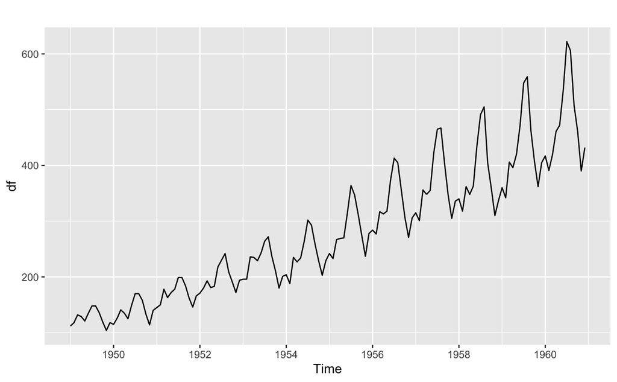

```r
autoplot(df)
```

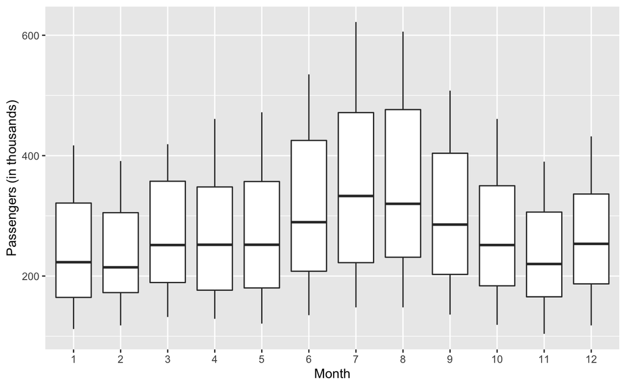

```r
ts_plot_season <- function(x = x) {
season <- cycle(x)
season.factor <- factor(season)
ggplot() +
  geom_boxplot(mapping = aes(x = season.factor,
                             y = x)) +
  labs(x = "Month", y =  "Passengers (in thousands)")
}

ts_plot_season(df)
```

# Decomposition

A given time series is thought to consist of three systematic components including level, trend, seasonality, and one non-systematic component called noise.

These components are defined as follows: - Level: The average value in the series. - Trend: The increasing or decreasing value in the series. - Seasonality: The repeating short-term cycle in the series. - Noise: The random variation in the series

An additive model is linear where changes over time are consistently made by the same amount. A multiplicative model is nonlinear, such as quadratic or exponential. Changes increase or decrease over time

Reviewing the line plot of Air Passenger data, it suggests that there may be a linear trend, but it is hard to be sure from eye-balling. There is also seasonality, but the amplitude (height) of the cycles appears to be increasing, suggesting that it is multiplicative.

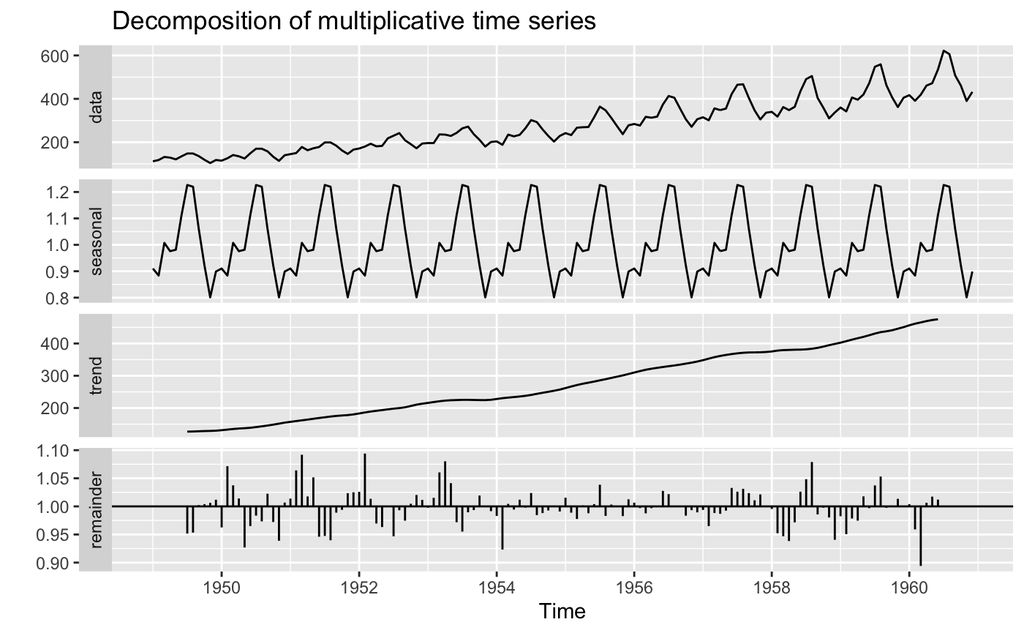

```r
decomposed_df <- decompose(df, type = "multiplicative")

autoplot(decomposed_df)
```

# Model and transform

## Testing for stationarity

Stationarity means your time series’s mean and variance is constant.

A stationary time series has a mean reverting behaviour.. means if it goes above your mean, it will come back towards mean and similar for downward.

To make a non stationary time series stationary.. you have to difference it until you see a mean reverting behaviour.

Mathematically, a stationary time series will have a constant:

- mean
- variance
- covariance

To test for stationarity, we can run a simple KPSS test. This test assumes a null hypothesis that a time series is stationary. That means, if the p-value of the test is less than 0.05, we can reject this hypothesis and assume the data is not stationary.

```r
kpss.test(df)
```

```
p-value smaller than printed p-value
```

```
    KPSS Test for Level Stationarity

data:  df
KPSS Level = 2.7395, Truncation lag parameter = 4, p-value = 0.01
```

In this case, our p-value is less than 0.05, meaning we should reject the null hypothesis. *Our data is not stationary.*

We need to do some transformations to make our data stationary.

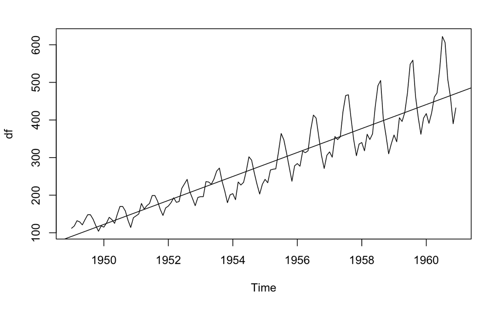

```r
plot(df)
abline(reg=lm(df~time(df)))
```

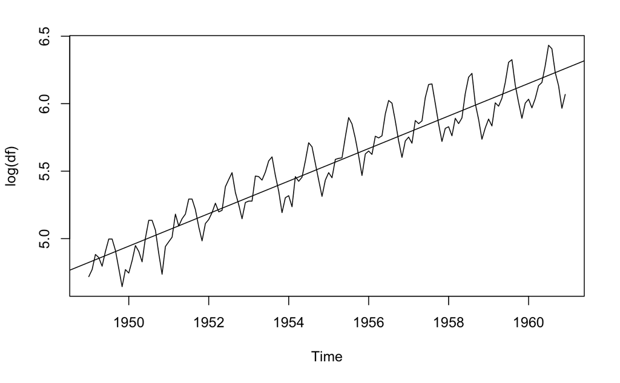

```r
plot(log(df))
abline(reg=lm(log(df)~time(log(df))))
```

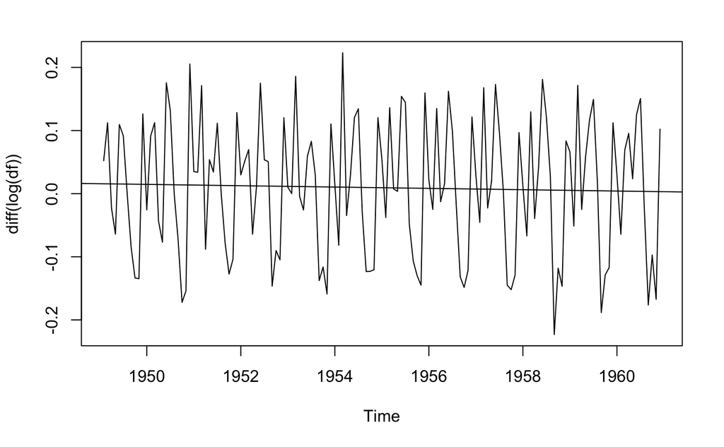

```r
plot(diff(log(df)))
abline(reg=lm(diff(log(df))~time(diff(log(df)))))
```

```r
kpss.test(diff(log(df)))
```

```
p-value greater than printed p-value
```

```
    KPSS Test for Level Stationarity

data:  diff(log(df))
KPSS Level = 0.028205, Truncation lag parameter = 4, p-value = 0.1
```

# ARIMA Model

ARIMA stands for Autoregressive Integrated Moving Average models. Univariate (single vector) ARIMA is a forecasting technique that projects the future values of a series based entirely on its own inertia.

```r
model <- auto.arima(log(df))
model
```

```
Series: log(df)
ARIMA(0,1,1)(0,1,1)[12]

Coefficients:
          ma1     sma1
      -0.4018  -0.5569
s.e.   0.0896   0.0731

sigma^2 estimated as 0.001371:  log likelihood=244.7
AIC=-483.4   AICc=-483.21   BIC=-474.77
```

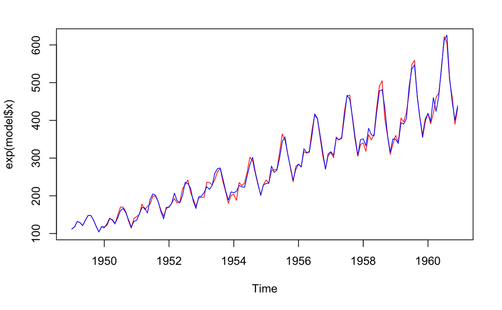

```r
plot(exp(model$x), col = "red")
lines(exp(model$fitted), col = "blue")
```

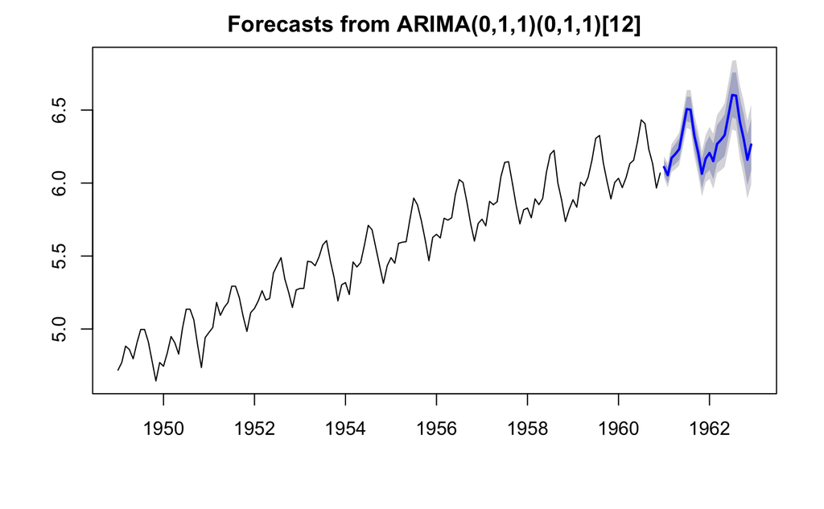

```r
forecast <- forecast(model, h=24)
plot(forecast)
```

```r
exp(forecast$mean)
```

```
          Jan      Feb      Mar      Apr      May      Jun      Jul      Aug      Sep
1961 450.4224 425.7172 479.0068 492.4045 509.0550 583.3449 670.0108 667.0776 558.1894
1962 495.9301 468.7289 527.4025 542.1538 560.4865 642.2823 737.7043 734.4748 614.5852
          Oct      Nov      Dec
1961 497.2078 429.8720 477.2426
1962 547.4424 473.3034 525.4600
```

```r
forecast$fitted
```

```
          Jan      Feb      Mar      Apr      May      Jun      Jul      Aug      Sep
1949 4.715775 4.769426 4.881883 4.859148 4.795318 4.904781 4.996704 4.996768 4.912340
1950 4.761720 4.804564 4.936755 4.918390 4.844878 4.952818 5.080390 5.113540 5.043739
1951 4.904769 5.023292 5.130134 5.124435 5.038982 5.247467 5.322947 5.305219 5.220054
1952 5.132428 5.193060 5.332849 5.230426 5.200342 5.299704 5.463068 5.448653 5.393845
1953 5.294335 5.337716 5.410695 5.380547 5.426626 5.560946 5.606463 5.611355 5.498649
1954 5.336903 5.355032 5.427092 5.410257 5.406916 5.534502 5.644028 5.709819 5.570085
1955 5.448989 5.453022 5.630379 5.569046 5.591122 5.703892 5.839823 5.875187 5.737125
1956 5.648973 5.621111 5.782628 5.751960 5.753905 5.887461 6.033021 6.006691 5.889632
1957 5.758186 5.728252 5.864354 5.855878 5.863703 6.012274 6.144609 6.122930 6.014283
1958 5.860666 5.806747 5.937210 5.891639 5.882456 6.046144 6.169401 6.176263 6.072640
1959 5.857251 5.825410 5.976001 5.966482 6.002135 6.192290 6.283740 6.304489 6.144778
1960 6.037369 5.984735 6.131890 6.049188 6.140512 6.295284 6.416340 6.439123 6.240189
          Oct      Nov      Dec
1949 4.778967 4.644378 4.773294
1950 4.916603 4.763722 4.883562
1951 5.062198 4.932957 5.133545
1952 5.221478 5.114387 5.284782
1953 5.361918 5.239558 5.348620
1954 5.444709 5.302877 5.434160
1955 5.620681 5.487439 5.598927
1956 5.754799 5.600161 5.740580
1957 5.871516 5.728700 5.855050
1958 5.887424 5.755663 5.860295
1959 6.008813 5.871777 5.985295
1960 6.103890 5.993307 6.083395
```

```r
hk <- read_csv("hk_electricity.csv")
head(hk)
```

| Year | Month | Domestic | Commercial | Industrial | Street lighting | Exports to the mainland of China | All groups |
| --- | --- | --- | --- | --- | --- | --- | --- |
| 1970 | Jan | 236 | 419 | 526 | 6 | 0 | 1186 |
| 1970 | Feb | 235 | 374 | 393 | 6 | 0 | 1008 |
| 1970 | Mar | 214 | 370 | 471 | 6 | 0 | 1061 |
| 1970 | Apr | 235 | 429 | 570 | 6 | 0 | 1240 |
| 1970 | May | 235 | 477 | 577 | 6 | 0 | 1295 |
| 1970 | Jun | 302 | 576 | 551 | 6 | 0 | 1435 |

```r
ts_hk <- as.ts(hk)
```

```
强制改变过程中产生了NA
```

```r
is.ts(ts_hk)
```

```
[1] TRUE
```

```r
head(ts_hk)
```

```
Time Series:
Start = 1
End = 6
Frequency = 1
  Year Month Domestic Commercial Industrial Street lighting
1 1970    NA      236        419        526               6
2 1970    NA      235        374        393               6
3 1970    NA      214        370        471               6
4 1970    NA      235        429        570               6
5 1970    NA      235        477        577               6
6 1970    NA      302        576        551               6
  Exports to the mainland of China All groups
1                                0       1186
2                                0       1008
3                                0       1061
4                                0       1240
5                                0       1295
6                                0       1435
```

```r
adf.test(df)
```

```
p-value smaller than printed p-value
```

```
    Augmented Dickey-Fuller Test

data:  df
Dickey-Fuller = -7.3186, Lag order = 5, p-value = 0.01
alternative hypothesis: stationary
```